# IWMLC: Meta-Analyses of Complexity Results

Chris Bentz

January 07, 2021

## LOAD PACKAGES

Load packages. If they are not installed yet on your local machine, use install.packages() to install them.

```r
library(readr)
library(MASS)
library(tidyr)
library(ggplot2)
library(scales)
library(plyr)
library(rcompanion)
library(rstatix)
```

## LOAD DATA

Load results of all participants in the UD track directly from github repo by using the “readr” library.

```r
brunato.results  <- read_csv("https://raw.githubusercontent.com/IWMLC/language-complexity-metrics/master/UDtrack/Brunato_venturi/Brunato-Venturi.csv")
coltekin.results  <- read_csv("https://raw.githubusercontent.com/IWMLC/language-complexity-metrics/master/UDtrack/Coltekin_rama/coltekin.csv")
semenuks.results  <- read_csv("https://raw.githubusercontent.com/IWMLC/language-complexity-metrics/master/UDtrack/Semenuks/Semenuks.csv")
sinnemaki.results  <- read_csv("https://raw.githubusercontent.com/IWMLC/language-complexity-metrics/master/UDtrack/Sinnemaki/Sinnemaki.csv")
sozinova.results  <- read_csv("https://raw.githubusercontent.com/IWMLC/language-complexity-metrics/master/UDtrack/Sozinova_etal/sozinova_etal.csv")
```

## DATA PRE-PROCESSING

Create a single data frame merging results together using the Reduce() and merge() functions of base R.

```r
results <- Reduce(merge, list(brunato.results, coltekin.results, semenuks.results, sinnemaki.results, sozinova.results)) # by default the merge() function uses columns with the same names to merge on, i.e. "id" and "language" in our case.
```

Give some simple statistics for this data frame of results.

```r
nrow(results) # i.e. number of different UD corpora
```

```
## [1] 63
```

```r
length(unique(results$language)) # i.e. number of different languages
```

```
## [1] 44
```

```r
unique(results$language) # output the language names
```

```
##  [1] "Afrikaans"           "Arabic"              "Bulgarian"
##  [4] "Catalan"             "Czech"               "Old Church Slavonic"
##  [7] "Chinese"             "Danish"              "German"
## [10] "Greek"               "Estonian"            "English"
## [13] "Basque"              "Persian"             "Finnish"
## [16] "French"              "Gothic"              "Ancient Greek"
## [19] "Hebrew"              "Hindi"               "Croatian"
## [22] "Hungarian"           "Indonesian"          "Italian"
## [25] "Japanese"            "Korean"              "Latin"
## [28] "Latvian"             "Dutch"               "Norwegian"
## [31] "Polish"              "Portuguese"          "Romanian"
## [34] "Russian"             "Slovak"              "Slovenian"
## [37] "Spanish"             "Serbian"             "Swedish"
## [40] "Turkish"             "Uyghur"              "Ukrainian"
## [43] "Urdu"                "Vietnamese"
```

```r
ncol(results)-2 # i.e. number of complexity measures
```

```
## [1] 27
```

Invert the values (by substracting them from 1) for the measure “CR_inflection_accurracy”. Note that higher values in the original measure mean *lower* rather than higher complexity.

```r
results$CR_inflection_accuracy <- 1-results$CR_inflection_accuracy
```

Scale all numerical columns to make them more comparable.

```r
results.scaled <- cbind(results[1:2], scale(results[3:29])) # add meta-information columns again
```

Transform data frame from wide format to long format (this is necessary for later plotting and analyses by columns rather than rows).

```r
results.long <- gather(results.scaled, key = measure, value = value, BV_n_tokens:SBS_DER)
```

Remove rows which contain NAs.

```r
results.long <- results.long[complete.cases(results.long), ]
nrow(results.long)
```

```
## [1] 1544
```

Select particular complexity measures (if needed).

```r
#selection <- c("BV_n_tokens", "BV_verbal_head_per_sent", "BV_verbal_root_perc","BV_avg_token_per_clause",
#              "BV_avg_links_len", "BV_avg_max_depth", "BV_avg_verb_edges", "BV_avg_subordinate_chain_len",
#              "BV_avg_subordinate_pre", "BV_avg_subordinate_post", "S_idMean", "S_idSD")
#results.long <- results.long[results.long$measure %in% selection, ]
```

## DENSITY DISTRIBUTIONS

Get mean, median, and standard deviation values.

```r
mu <- ddply(results.long, "language", summarise, grp.mean = mean(value)) # get mean values for each language
med <- ddply(results.long, "language", summarise, grp.median = median(value)) # get median values for each language
sdev <- ddply(results.long, "language", summarise, grp.sd = sd(value)) # get standard deviation values for each language
```

Plot density distributions with indication of median (mean) values.

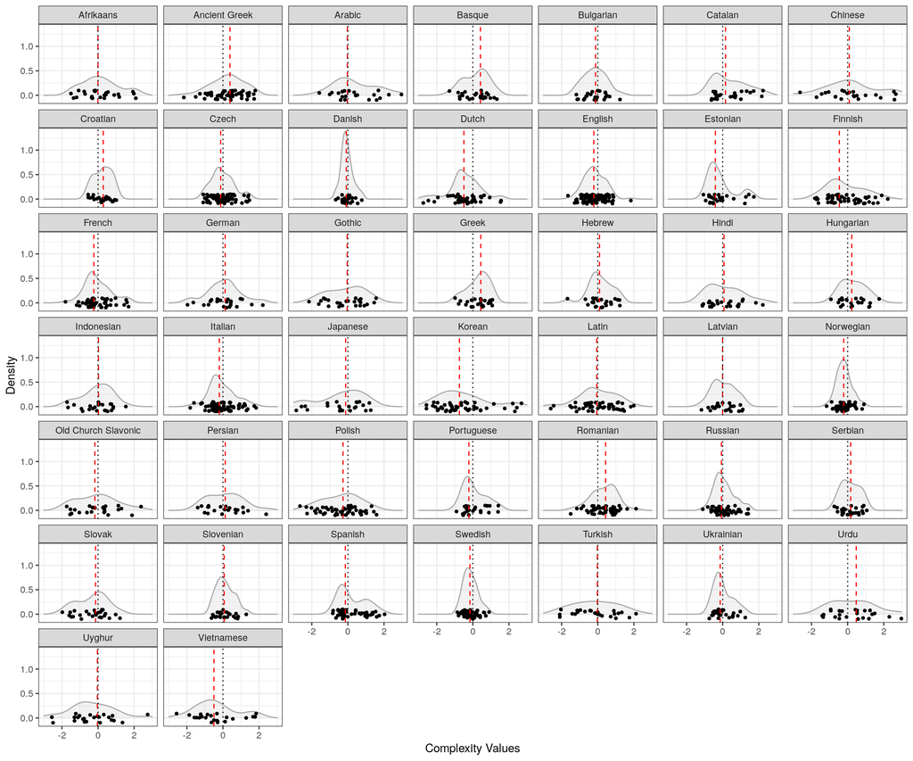

```r
density.plot <- ggplot(results.long, aes(x = value)) +
 #geom_histogram(aes(y = ..density..), colour = "black", fill = "light grey",
                #binwidth = 0.1) +
 geom_density(alpha = .2, fill = "grey", color = "darkgrey") +
 geom_jitter(data = results.long, aes(x = value, y = 0),
             size = 1, height = 0.1, width = 0) +
 facet_wrap(~ language) +
 # geom_vline(data = mu, aes(xintercept=grp.mean),
 #           linetype = "dotted") +
 geom_vline(data = med, aes(xintercept = grp.median),
             linetype = "dashed", color = "red") +
 geom_vline(aes(xintercept = 0), linetype = "dotted") +
 labs(x = "Complexity Values", y = "Density") +
 xlim(-3, 3) +
 theme_bw()
print(density.plot)
```

Safe figure to file.

```r
ggsave("~/Github/ComplexityMetaAnalyses/Figures/EquiCompl/density_plot.pdf", density.plot,
       dpi = 300, scale = 1, width = 12, height = 10, device = cairo_pdf)
```

## STATISTICAL TESTS

Run statistical tests to assess whether the aggregate complexity distributions for certain pairs of languages differ signficantly from one another. Note that for this sample of 44 languages there are 44*(44-1)/2 = 946 possible pairwise comparisons.

# Overview of median values

Give an overview of languages with highest and lowest median complexity values.

```r
stats.df <- cbind(mu, med[, 2], sdev[, 2])
colnames(stats.df) <- c("language", "mu", "med", "sdev")
stats.df.sorted <- stats.df[order(-stats.df$med),]
# round values to two decimal places,  the "-1" excludes column 1
stats.df.sorted[, -1] <- round(stats.df.sorted[, -1], 2)
print(stats.df.sorted)
```

```
##               language    mu   med sdev
## 42                Urdu  0.44  0.48 1.46
## 18               Greek  0.30  0.44 0.60
## 33            Romanian  0.34  0.43 0.72
## 4               Basque  0.16  0.42 0.69
## 2        Ancient Greek  0.25  0.39 0.90
## 8             Croatian  0.25  0.29 0.48
## 21           Hungarian  0.29  0.23 1.30
## 35             Serbian  0.16  0.17 0.52
## 6              Catalan  0.39  0.16 0.91
## 30             Persian  0.11  0.13 1.45
## 16              German  0.04  0.12 0.94
## 19              Hebrew  0.15  0.10 0.67
## 7              Chinese  0.17  0.09 1.67
## 20               Hindi  0.24  0.07 1.15
```

[output cut: 30 more lines]

Output data frame as csv file.

```r
write.csv(stats.df.sorted, file = "~/Github/ComplexityMetaAnalyses/Tables/descriptiveStats.csv", row.names = F)
```

# Normality

The assumption that the tested data stems from a normally distributed population is often necessary for the mathematical proofs underlying standard statistical techniques. We might apply normality tests to check for this assumption (e.g. Baayen 2008, p. 73), but some statisticians advice against such pre-tests, since they are often too sensitive (MacDonald 2014, p. 133-136, Rasch et al. (2020), p. 67). In fact, Rasch et al. (2020, p. xi) argue based on earlier simulation studies that almost all standard statistical tests are fairly robust against deviations from normality. However, it is still advisable to check for gross deviations from normality in the data. One common way of doing this is quantile-quantile plots. The points should here roughly follow a straight line (Crawley 2007, p. 281).

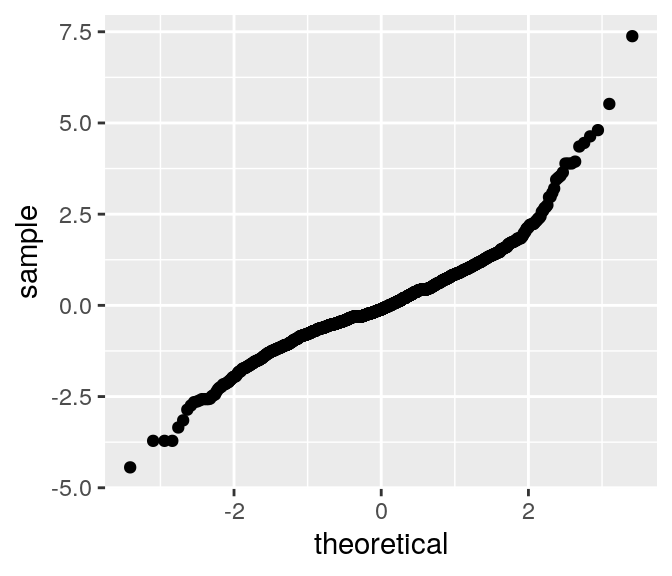

```r
ggplot(results.long, aes(sample = value)) +
  stat_qq()
```

# Statistical tests

Select a statistical test: Standard t-tests can be used to assess significant differences in the means of the pseudo-complexity distributions, if we assume that the underlying population distributions are normal. Wilcoxon tests are a non-parametric alternative, i.e. they do not make assumptions about the underlying population distribution, e.g. normality (Crawley 2007, p. 283; Baayen 2008, p. 77). Since there are some deviations from normality visible in the QQ-Plot above, we here choose a Wilcoxon test. If we supply two data vectors, then by default the command wilcox.test() runs a Wilcoxon rank sum test (for unpaired samples), and with “paired = T” a Wilcoxon signed rank test. Note that while the same measurement procedures were used here across different languages (and corresponding text samples) to assess different types of complexity, there are sometimes NAs in the original data. We thus have to consider the resulting vectors “unpaired”. Note that pairwise.wilcox.test() is a function of the R-core stats package which runs multiple tests, i.e. for all groups in the “language” column in our case.

P-value adjustment for multiple comparisons: In case of multiple testing, we should account for the fact that the likelihood of finding a significant result by chance increases with the number of statistical tests. One of the most conservative methods to account for this is the so-called Bonferroni correction, i.e. multiplying the p-values with the number of tests. This method is appropriate when tests are independent of one another (MacDonald 2014, p. 254-260). Since we here run pairwise tests by languages, our tests are not independent (the same language is tested against others multiple times). We therefore apply the so-called Holm-Bonferroni method, which is less conservative. It does not assume independence between tests (see the descriptions in the vignette invoked by the command “?p.adjust()”).

```r
p.values <- pairwise.wilcox.test(jitter(results.long$value), results.long$language,
                     paired = F, p.adjust.method = "holm") # we add some random noise here to the value vector with
# the function jitter(), since we otherwise get warnings due to ties in the data
p.values
```

```
##
##  Pairwise comparisons using Wilcoxon rank sum test
##
## data:  jitter(results.long$value) and results.long$language
##
##                     Afrikaans Ancient Greek Arabic Basque Bulgarian Catalan
## Ancient Greek       1.0000    -             -      -      -         -
## Arabic              1.0000    1.0000        -      -      -         -
## Basque              1.0000    1.0000        1.0000 -      -         -
## Bulgarian           1.0000    1.0000        1.0000 1.0000 -         -
## Catalan             1.0000    1.0000        1.0000 1.0000 1.0000    -
## Chinese             1.0000    1.0000        1.0000 1.0000 1.0000    1.0000
## Croatian            1.0000    1.0000        1.0000 1.0000 1.0000    1.0000
## Czech               1.0000    1.0000        1.0000 1.0000 1.0000    1.0000
## Danish              1.0000    1.0000        1.0000 1.0000 1.0000    1.0000
## Dutch               1.0000    0.1385        1.0000 1.0000 1.0000    0.5707
## English             1.0000    1.0000        1.0000 1.0000 1.0000    1.0000
## Estonian            1.0000    1.0000        1.0000 1.0000 1.0000    1.0000
## Finnish             1.0000    1.0000        1.0000 1.0000 1.0000    1.0000
## French              1.0000    1.0000        1.0000 1.0000 1.0000    1.0000
## German              1.0000    1.0000        1.0000 1.0000 1.0000    1.0000
## Gothic              1.0000    1.0000        1.0000 1.0000 1.0000    1.0000
## Greek               1.0000    1.0000        1.0000 1.0000 1.0000    1.0000
## Hebrew              1.0000    1.0000        1.0000 1.0000 1.0000    1.0000
## Hindi               1.0000    1.0000        1.0000 1.0000 1.0000    1.0000
## Hungarian           1.0000    1.0000        1.0000 1.0000 1.0000    1.0000
## Indonesian          1.0000    1.0000        1.0000 1.0000 1.0000    1.0000
## Italian             1.0000    1.0000        1.0000 1.0000 1.0000    1.0000
## Japanese            1.0000    1.0000        1.0000 1.0000 1.0000    1.0000
## Korean              1.0000    1.0000        1.0000 1.0000 1.0000    1.0000
## Latin               1.0000    1.0000        1.0000 1.0000 1.0000    1.0000
## Latvian             1.0000    1.0000        1.0000 1.0000 1.0000    1.0000
## Norwegian           1.0000    1.0000        1.0000 1.0000 1.0000    1.0000
## Old Church Slavonic 1.0000    1.0000        1.0000 1.0000 1.0000    1.0000
## Persian             1.0000    1.0000        1.0000 1.0000 1.0000    1.0000
## Polish              1.0000    1.0000        1.0000 1.0000 1.0000    1.0000
## Portuguese          1.0000    1.0000        1.0000 1.0000 1.0000    1.0000
## Romanian            1.0000    1.0000        1.0000 1.0000 1.0000    1.0000
## Russian             1.0000    1.0000        1.0000 1.0000 1.0000    1.0000
## Serbian             1.0000    1.0000        1.0000 1.0000 1.0000    1.0000
```

[output cut: 260 more lines]

```
## Portuguese          -         -      -
## Romanian            -         -      -
## Russian             -         -      -
## Serbian             -         -      -
## Slovak              -         -      -
## Slovenian           -         -      -
## Spanish             -         -      -
## Swedish             -         -      -
## Turkish             -         -      -
## Ukrainian           -         -      -
## Urdu                1.0000    -      -
## Uyghur              1.0000    1.0000 -
## Vietnamese          1.0000    1.0000 1.0000
##
## P value adjustment method: holm
```

## Effect Size

```r
effect.sizes <- wilcox_effsize(results.long, value ~ language, paired = F)
print(effect.sizes)
```

```
## # A tibble: 946 x 7
##    .y.   group1    group2        effsize    n1    n2 magnitude
##  * <chr> <chr>     <chr>           <dbl> <int> <int> <ord>
##  1 value Afrikaans Ancient Greek 0.0817     24    48 small
##  2 value Afrikaans Arabic        0.0685     24    24 small
##  3 value Afrikaans Basque        0.0643     24    25 small
##  4 value Afrikaans Bulgarian     0.119      24    24 small
##  5 value Afrikaans Catalan       0.104      24    24 small
##  6 value Afrikaans Chinese       0.00143    24    25 small
##  7 value Afrikaans Croatian      0.107      24    25 small
##  8 value Afrikaans Czech         0.0521     24    75 small
##  9 value Afrikaans Danish        0.0643     24    25 small
## 10 value Afrikaans Dutch         0.249      24    48 small
## # … with 936 more rows
```

## Effect Size Heatmap

Plot a heatmap with effect sizes to get a better overview.

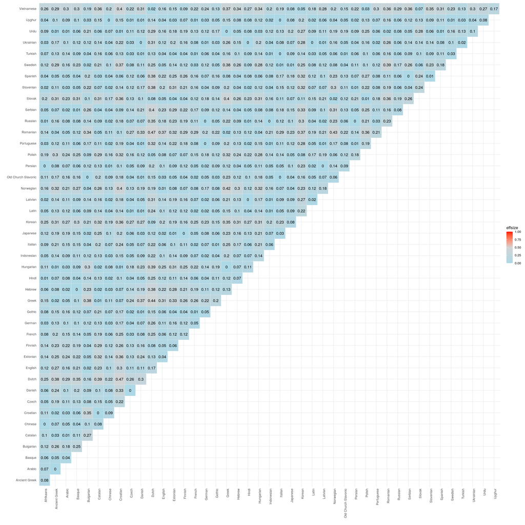

```r
effect.sizes.plot <- ggplot(as.data.frame(effect.sizes), aes(group1, group2)) +
  geom_tile(aes(fill = effsize), color = "white") +
  scale_fill_gradient2(low = "light blue", mid = "light grey", high = "red",
                       midpoint = 0.5, limit = c(0,1)) +
  geom_text(aes(label = round(effsize, 2))) +
  labs(x = "", y = "") +
  theme_minimal() +
  theme(axis.text.x = element_text(angle = 90, hjust = 1))
effect.sizes.plot
```

Safe figure to file.

```r
ggsave("~/Github/ComplexityMetaAnalyses/Figures/EquiCompl/effectSize_plot.pdf", effect.sizes.plot,
       dpi = 300, scale = 1, width = 20, height = 20, device = cairo_pdf)
```

# Interpretation:

So, given the data, methods, and languages in this meta study, there is overboarding evidence that languages are equi-complex, if different dimensions of complexity are aggregated.

# References

Baayen, R. H. (2008). Analyzing linguistic data: A practical introduction using statistics in R. Cambridge University Press.

Cahusac, P. M. B. (2021). Evidence-based statistics. John Wiley & Sons.

Crawley, M. J. (2007). The R book. John Wiley & Sons Ltd.

Ehret, K. and B. Szmrecsanyi (2016). An information-theoretic approach to assess linguistic complexity. In: R. Baechler & G. Seiler (eds.), Complexity, Isolation, and Variation, 71-94. Berlin: de Gruyter.

Kruschke, J. K. (2012). Bayesian estimation supersedes the t test. Journal of Experimental Psychology.

McDonald, J.H. (2014). Handbook of Biological Statistics (3rd ed.). Sparky House Publishing, Baltimore, Maryland. online at http://www.biostathandbook.com

Patil, I. (2020). Test and effect size details. online at https://cran.r-project.org/web/packages/statsExpressions/vignettes/stats_details.html.

Rasch, D., Verdooren, R., and J. Pilz (2020). Applied statistics. Theory and problem solutions with R. John Wiley & Sons Ltd.